# Omitted Variable-A-Palooza

# The Data

This data is from the SBC LTER. We have 14 years of data ranging from 2004 to 2017. There are 10 sites and 37 transects. Here’s the distribution of transects per site.

```r
combined_data %>%
  group_by(SITE) %>%
  summarize(number_of_transects = length(unique(TRANSECT)))
```

```
## # A tibble: 10 x 2
##    SITE  number_of_transects
##    <chr>               <int>
##  1 ABUR                    2
##  2 AHND                    2
##  3 AQUE                    6
##  4 BULL                    3
##  5 CARP                    8
##  6 GOLB                    2
##  7 MOHK                    2
##  8 NAPL                    8
##  9 SCDI                    2
## 10 SCTW                    2
```

```r
library(readxl)
library(rnaturalearth)
library(sf)
sites <- read_excel("../raw_data/lter_sites.xlsx") %>%
  st_as_sf(coords = c("Long", "Lat"), crs = 4326)
coast <- ne_coastline(scale = 50, returnclass = "sf")


countries_10_sf <- ne_download(scale = 10, category = 'cultural', type = 'countries', returnclass="sf")
ocean_10_sf <- ne_download(scale = 10, category = 'physical', type = 'ocean', returnclass="sf")
```

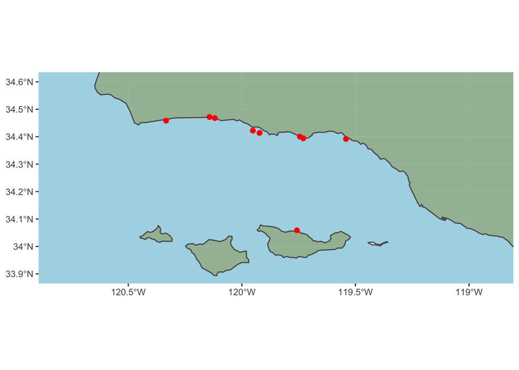

```r
ggplot() +
  geom_sf(data = countries_10_sf, fill="palegreen4", alpha=0.5) +
  geom_sf(data = ocean_10_sf, fill="lightblue") +
  geom_sf(data = sites, size = 2, color = "red") +
  coord_sf(xlim = c(-120.8, -118.9), ylim = c(33.9, 34.6))
```

In this dataset, we have a number of quantities at the transect level. We have kelp stipes per transect, subcanopy kelp stipes per transect, % cover invertebrates per transect, % cover of algae per transect, and # of urchins in 6 quads along the transect.

Broadly, the data data looks like this

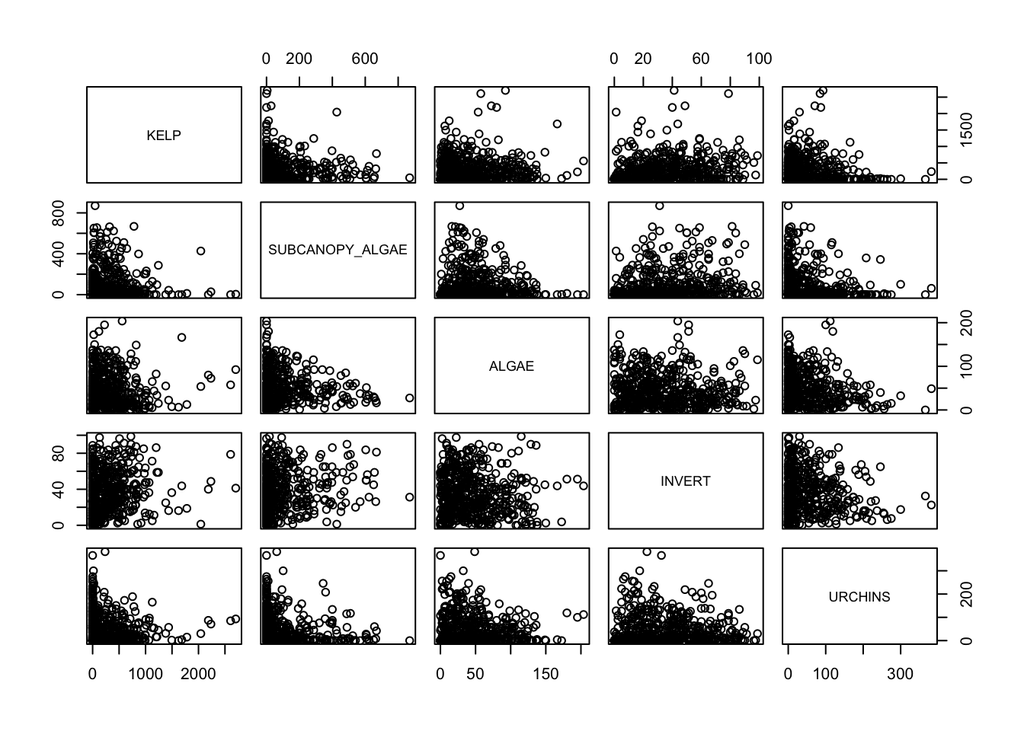

```r
pairs(combined_data[,-c(1:3)])
```

# The System

With these variables, the DAG for the system looks like this.

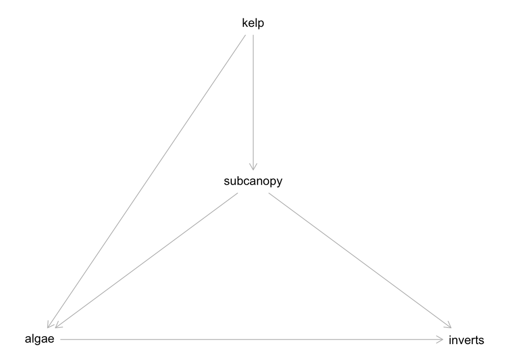

```r
system_dag_simple <- dagitty("dag{
kelp -> algae -> inverts
kelp -> subcanopy -> algae
subcanopy -> inverts
}")

coordinates(system_dag_simple) <- list(x = c(algae = 1, inverts = 3,kelp = 2, subcanopy = 2),
                                y = c(algae = 4,inverts = 4,kelp = 2, subcanopy = 3))


plot(system_dag_simple)
```

If we want to incorporate unmeasured variables - correlated with site and time - we have something more like

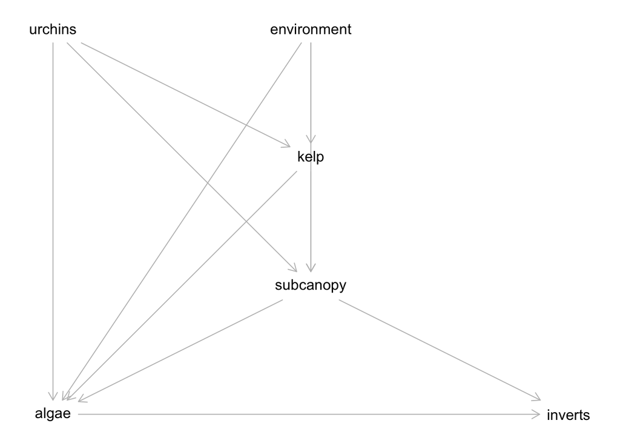

```r
system_dag <- dagitty('dag{
kelp -> algae -> inverts
kelp -> subcanopy -> algae
subcanopy -> inverts
urchins -> kelp
urchins -> subcanopy
urchins -> algae
environment -> kelp
environment -> algae
environment -> subcanopy
}')

coordinates(system_dag) <- list(x = c(algae = 1,environment = 2, inverts = 3,kelp = 2, subcanopy = 2, urchins = 1),
                                y = c(algae = 4,environment = 1, inverts = 4,kelp = 2, subcanopy = 3, urchins = 1))

plot(system_dag)
```

## A Bivariate Relationship

We know that kelp outcompetes benthic algae by shading it. When we look at the data as a whole, there is a trend, but is exceedingly weak. If even positive.

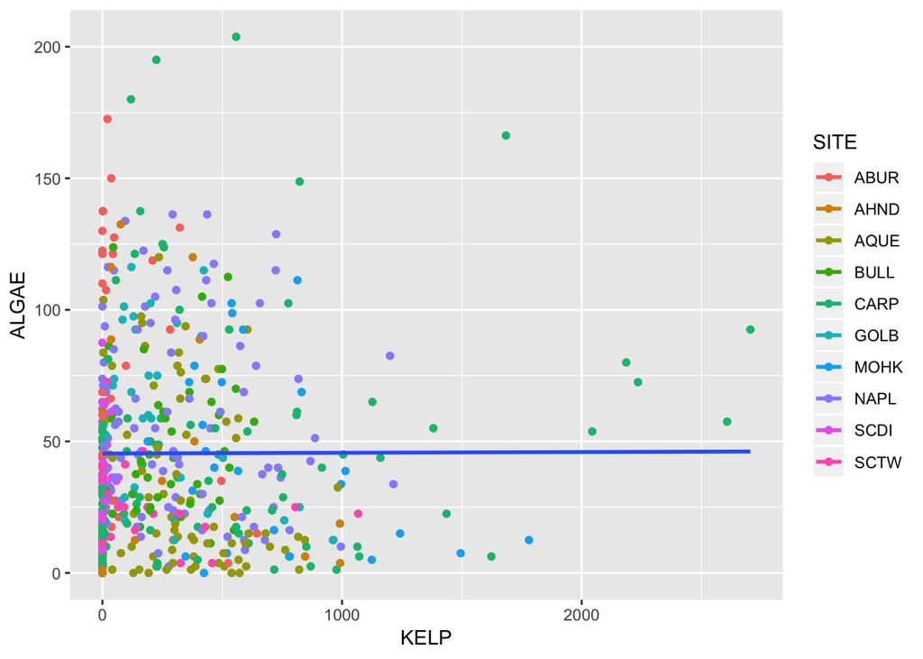

```r
ggplot(combined_data  ,
       aes(x = KELP, y = ALGAE, color = SITE)) +
  geom_point() +
  stat_smooth(method = "lm", fill = NA, mapping = aes(group = 1))
```

This is unsurprising given the multivariate model of the system above. In particular, we can see that the environment is clearly a backdoor. Further, urchins can function as an omitted variable, although we’ve attempted to control that here by subsetting the data.

So, how would we model this relationship to get the clearest and cleanest causal inference? Parrticularly without measurements of environmental omitted variables?

# Naieve Fit

```r
mod_naieve <- lm(ALGAE ~ KELP,
                  data = combined_data)

tidy(mod_naieve)
```

```
## # A tibble: 2 x 5
##   term         estimate std.error statistic  p.value
##   <chr>           <dbl>     <dbl>     <dbl>    <dbl>
## 1 (Intercept) 45.4        2.11      21.6    5.62e-74
## 2 KELP         0.000280   0.00437    0.0641 9.49e- 1
```

# Random Effects

```r
mod_random <- lme(ALGAE ~ KELP,
                  random = list(~1|SITE, (~1|TRANSECT)),
                  data = combined_data)

tidy(mod_random, effects = "fixed")
```

```
## # A tibble: 2 x 5
##   term        estimate std.error statistic  p.value
##   <chr>          <dbl>     <dbl>     <dbl>    <dbl>
## 1 (Intercept)  50.3      4.16        12.1  1.48e-29
## 2 KELP         -0.0162   0.00418     -3.87 1.23e- 4
```

# Fixed Effects

```r
mod_fixed <- lm(ALGAE ~ KELP + SITE + factor(TRANSECT),
                  data = combined_data)

tidy(mod_fixed)[1:2,]
```

```
## # A tibble: 2 x 5
##   term         estimate std.error statistic  p.value
##   <chr>           <dbl>     <dbl>     <dbl>    <dbl>
## 1 (Intercept)  81.0       6.95        11.7  6.28e-28
## 2 KELP         -0.00522   0.00448     -1.17 2.45e- 1
```

# Group Centered Predictor

```r
combined_data_gmp<- combined_data %>%
  group_by(SITE, TRANSECT) %>%
  mutate(TRANSECT_MEAN_KELP = mean(KELP) ) %>%
  ungroup()


mod_gmp<- lme(ALGAE ~ KELP + TRANSECT_MEAN_KELP,
                  random = list(~1|SITE, (~1|TRANSECT)),
                  data = combined_data_gmp)

tidy(mod_gmp, effects = "fixed")
```

```
## # A tibble: 3 x 5
##   term               estimate std.error statistic     p.value
##   <chr>                 <dbl>     <dbl>     <dbl>       <dbl>
## 1 (Intercept)         24.9      7.85         3.18 0.00158
## 2 KELP                -0.0193   0.00428     -4.50 0.00000840
## 3 TRANSECT_MEAN_KELP   0.0980   0.0142       6.93 0.000000236
```

# Group Mean Centering

```r
combined_data_gmc <- combined_data_gmp %>%
  group_by(SITE, TRANSECT) %>%
  mutate(KELP_ANOMALY = KELP - TRANSECT_MEAN_KELP) %>%
  ungroup()


mod_gmc<- lme(ALGAE ~ KELP_ANOMALY + TRANSECT_MEAN_KELP,
                  random = list(~1|SITE, (~1|TRANSECT)),
                  data = combined_data_gmc)

tidy(mod_gmc, effects = "fixed")
```

```
## # A tibble: 3 x 5
##   term               estimate std.error statistic    p.value
##   <chr>                 <dbl>     <dbl>     <dbl>      <dbl>
## 1 (Intercept)         24.9      7.85         3.18 0.00158
## 2 KELP_ANOMALY        -0.0193   0.00428     -4.50 0.00000840
## 3 TRANSECT_MEAN_KELP   0.0787   0.0135       5.84 0.00000375
```

# Differencing

```r
diff_data <- combined_data %>%
  group_by(SITE, TRANSECT) %>%
  mutate(KELP_CHANGE = (KELP - lag(KELP)),
         ALGAE_CHANGE = (ALGAE - lag(ALGAE))) %>%
  ungroup()

mod_diff<- lme(ALGAE_CHANGE ~ KELP_CHANGE,
                  random = list(~1|SITE, (~1|TRANSECT)),
                  data = diff_data,
              na.action = na.omit)

tidy(mod_diff, effects = "fixed")
```

```
## # A tibble: 2 x 5
##   term        estimate std.error statistic      p.value
##   <chr>          <dbl>     <dbl>     <dbl>        <dbl>
## 1 (Intercept)   0.645    1.79        0.360 0.719
## 2 KELP_CHANGE  -0.0265   0.00477    -5.55  0.0000000490
```